# Lab 1: Séries de TV

André Victor de Andrade Lopes

6 de maio de 2018

# Os Dados

Os dados utilizados foram extraidos do IMDB em Julho de 2017. Eles estão disponíveis em uma tabela csv que também está no repositório (data/series_from_imdb.csv).

Cada linha da tabela é referente a média de avaliação de um episódio de uma série no IMDB dados. Cada linha é composta por: Nome da série, Episódio (em relação ao total da série), Episódio (em relação a temporada), Temporada, URL (link para a pagina do IMDB), Média de avaliação, Total de Votos, e uma sequencia de valores rx, onde 1<=r<=10, rx representando a proporção dos votos com a nota x. No total, há dados sobre 511 séries, totalizando 32.070 episódios.

```r
dados = read_csv(here("data/series_from_imdb.csv"),
                    progress = FALSE,
                    col_types = cols(series_name = col_character(),
                                     episode = col_character(),
                                     url = col_character(),
                                     season = col_character()))

series = dados %>%
           group_by(series_name) %>%
            summarise(n = n(),
                      max_user_votes = max(user_votes),
                      min_user_votes = min(user_votes),
                      seasons = max(season))
```

# 1. Quanto maior o numero de temporadas, maior a média de avalição de uma série?

Quando uma série dura muito tempo, o que acredita é que apenas as pessoas que realmente gostam da série, continuam assistindo. Mas, isso quer dizer que a média geral da série será mais alta?

Primeiro agrupamos o conjunto de dados pelo nome da série e juntamos a ele a quantidade de episódios da série, numero de temporadas e a média geral da série (média das avaliações de cada episódio). Ou seja, cada ponto do gráfico abaixo é referente a uma série que tem x temporadas cuja média das avaliações é y.

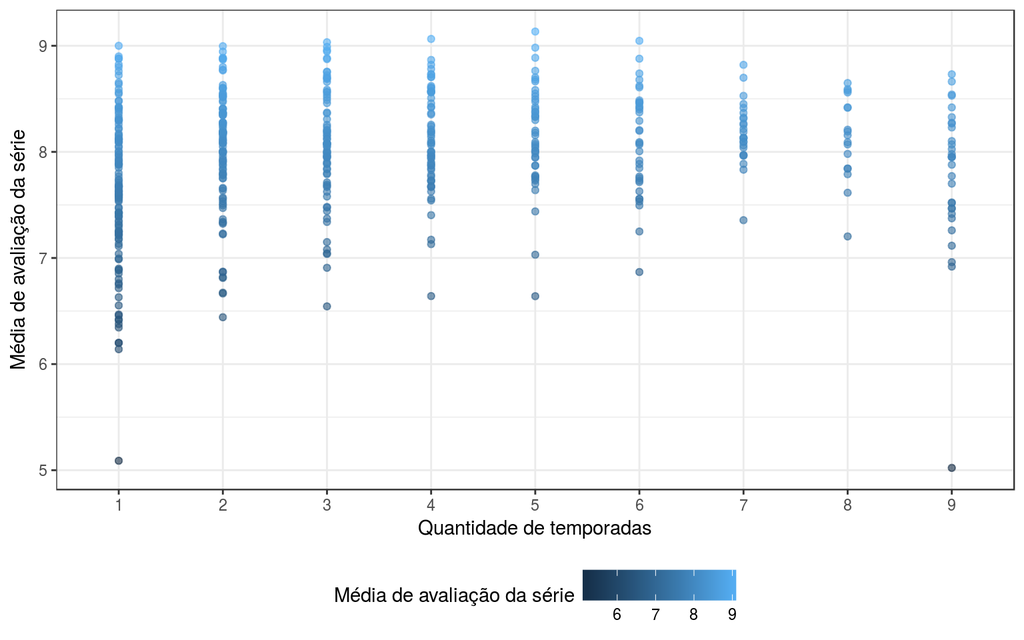

```r
dados_temporadas = dados %>%
            group_by(series_name) %>%
            summarise(n = n(),
                      seasons = max(season),
                      mean_rating= mean(user_rating))
ggplot(dados_temporadas,
       aes(seasons,
           mean_rating,
           color= mean_rating)) +
    geom_point(alpha = .6) +
    labs(x = "Quantidade de temporadas",
         y = "Média de avaliação da série",
         color = "Média de avaliação da série")+
    theme(legend.position="bottom")
```

Como os pontos estão muito juntos, a teoria de uma relação entre a quantidade de temproadas e a média geral fica um pouco dificil de ser elaborada. Embora pareça ter uma correlação positiva até a quinta temporada. Porém vamos tentar ver essa distribuição com um boxplot: Em rosa está o valor do primeiro quartil.

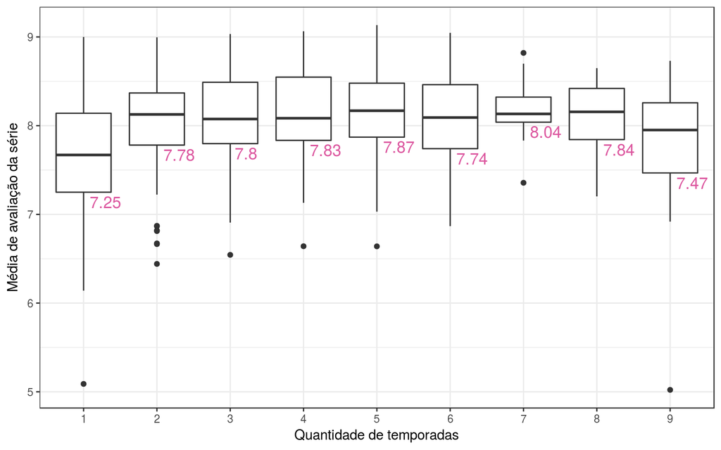

```r
primeiro_quartil <- function(x){
   return(c(y = unname(quantile(x, 0.25)), label = round(unname(quantile(x, 0.25)), digits=2)))
}

ggplot(dados_temporadas,
       aes(seasons,
           mean_rating),
       color='dodgerblue3') +
    geom_boxplot() +
    stat_summary(fun.data = primeiro_quartil,
                 geom = "text",
                 alpha = .7,
                 color='deeppink3',
                 aes(hjust=-0.2,
                     vjust=1.3,
                     size= 2)) +
    labs(x = "Quantidade de temporadas",
         y = "Média de avaliação da série") +
        theme(legend.position="none")
```

Com ajuda do boxplot, podemos perceber um comportamento: a posição do primeiro quartil parece subir, até chegar na quinta temporada onde começa a descer.  
A partir de tentativa e erro, estimei uma função para tentar aproximar o valor do primeiro quartil dos valores: F(x) = -0.03*(x-5)² + 7.85.  
Essa função representa uma parábola com o vertice em (5, 7.85).

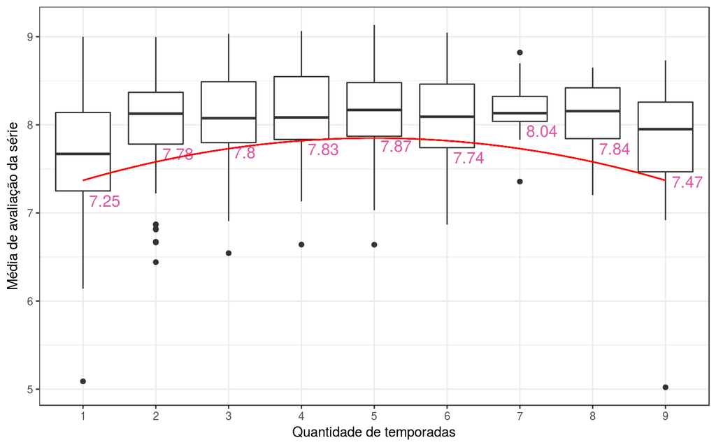

```r
ggplot(dados_temporadas, aes(seasons, mean_rating)) +
    geom_boxplot() +
    stat_function(fun = function(x) -0.03*(x - 5)^2  + 7.85,
                  color="red") +
    stat_summary(fun.data = primeiro_quartil,
                 geom = "text",
                 alpha = .7,
                 color='deeppink3',
                 aes(hjust=-0.2,
                     vjust=1.3,
                     size= 2)) +
    labs(x = "Quantidade de temporadas",
         y = "Média de avaliação da série") +
        theme(legend.position="none")
```

Se temos que a média geral de cerca de 75% dos programas estão acima do valor da função e ela cresce até x = 5, ou seja, até a quinta temporada, temos que, se a serie dura até 5 temporadas, quanto maior o numero de temporadas, maior a média geral. Porém se a série dura mais que isso, a premissa não é verdadeira.  
Por tanto, a ideia é que a série tenha uma quantidade de temporadas suficientes para desenvolver a história e os personagens, mas que não se prolongue desnecessariamente.

Podemos ver os valores estimados da função em comparação com o verdadeiro valor e o erro proporcional da aproximação em relação ao valor real.

```r
dados_temporadas_grouped <- dados_temporadas %>%
    group_by(seasons) %>%
    summarise(real= unname(quantile(mean_rating,
                                    0.25)))

comparacao <- data.frame(seasons=c(1, 2, 3, 4, 5, 6, 7,8,9))
comparacao <- transform(comparacao, aproximado = -0.03*(seasons - 5)^2  + 7.85)
comparacao <- merge(comparacao, dados_temporadas_grouped,by="seasons")
comparacao <- transform(comparacao, erro_proporcional = round(abs(real-aproximado)/real ,
                                                              digits= 2))

comparacao
```

```
  seasons aproximado     real erro_proporcional
1       1       7.37 7.250000              0.02
2       2       7.58 7.781303              0.03
3       3       7.73 7.797619              0.01
4       4       7.82 7.834470              0.00
5       5       7.85 7.870705              0.00
6       6       7.82 7.741015              0.01
7       7       7.73 8.039344              0.04
8       8       7.58 7.843269              0.03
9       9       7.37 7.467240              0.01
```

Adicionalmente, podemos ver a correlação linear entre a quantidade de temporadas e média geral.

```r
dados_temporadas$seasons = as.numeric(dados_temporadas$seasons)
cor(dados_temporadas$seasons, dados_temporadas$mean_rating);
```

```
[1] 0.1562713
```

Como era esperado após a analise dos gráficos, não é possível dizer que existe uma correlação linear forte. Ainda sim, essa correlação, mesmo que fraca, é positiva.

# 2. Séries canceladas na primeira temporada apresentam uma média decrescente ao logo da temporada?

Para a analise, iremos filtrar os dados para exibir apenas as séries que foram canceladas na primeira temporada.  
Essa informação não está explicita na tabela, porém o link para a página no IMDB esta disponível. A partir do link podemos checar o ano de término da série e informações sobre a série (como por exemplo, o caso de ser uma série limitada onde só há uma temporada). A partir de então, foram selecionadas 10 séries canceladas para serem utilizadas na analise.  
Dividiremos as séries em dois grupos para uma melhor visualização dos gráficos

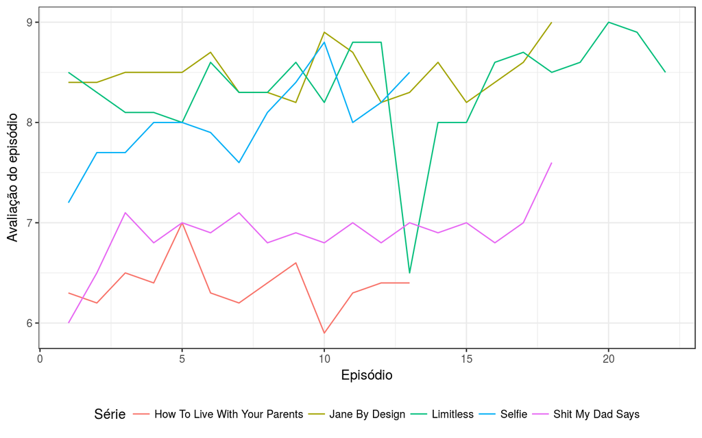

```r
canceladas1 = c('How To Live With Your Parents', 'Jane By Design', 'Limitless', 'Selfie', 'Shit My Dad Says')
canceladas2 = c('State Of Georgia', 'Terra Nova','The New Normal', 'The Secret Circle', 'Zero Hour')
dados_canceladas1 <- dados %>%
    filter(series_name %in% canceladas1)
dados_canceladas2 <- dados %>%
    filter(series_name %in% canceladas2)
dados_canceladas = rbind(dados_canceladas1, dados_canceladas2)

ggplot(dados_canceladas1,
       aes(x = series_ep,
           y= user_rating,
           color=series_name)) +
        geom_line() +
    labs(x = "Episódio",
         y = "Avaliação do episódio",
         color = "Série") +
        theme(legend.position="bottom")
```

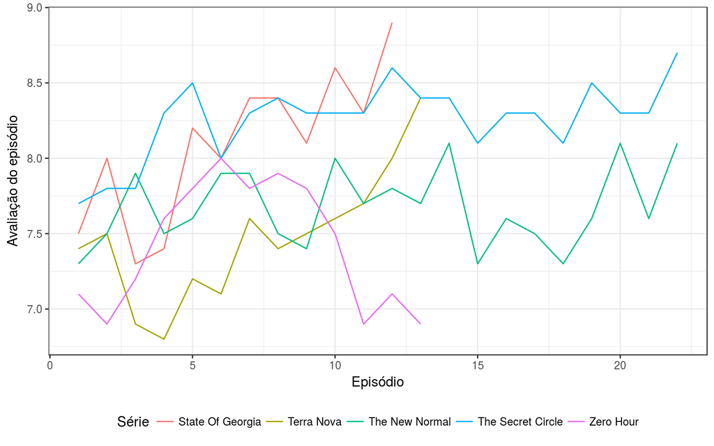

```r
ggplot(dados_canceladas2,
       aes(x = series_ep,
           y = user_rating,
           color=series_name)) +
        geom_line() +
    labs(x = "Episódio",
         y = "Avaliação do episódio",
         color = "Série") +
        theme(legend.position="bottom")
```

```r
series_canceladas_comparacao<- data.frame(series_name = unique(dados_canceladas1$series_name))
series_canceladas_comparacao<- rbind(series_canceladas_comparacao, data.frame(series_name = unique(dados_canceladas2$series_name)))

dados_canceladas_grouped <- dados_canceladas %>%
    group_by(series_name) %>%
    summarise(ultimo_ep = n(),
              mediana = mean(user_rating))
getEpisodesRatings <- function(eps, names){
    result = c();
    for(index in 1:length(eps)){
        result = c(result, subset(dados_canceladas$user_rating, dados_canceladas$series_ep == eps[index] & dados_canceladas$series_name == names[index]));
    }
    return(result);
}

dados_canceladas_grouped <- transform(dados_canceladas_grouped, antepenultimo_episodio = getEpisodesRatings(ultimo_ep-2 ,series_name))
dados_canceladas_grouped <- transform(dados_canceladas_grouped, penultimo_episodio = getEpisodesRatings(ultimo_ep-1 ,series_name))
dados_canceladas_grouped <- transform(dados_canceladas_grouped, ultimo_episodio = getEpisodesRatings(ultimo_ep ,series_name))
dados_canceladas_grouped
```

```
                     series_name ultimo_ep  mediana antepenultimo_episodio
1  How To Live With Your Parents        13 6.376923                    6.3
2                 Jane By Design        18 8.483333                    8.4
3                      Limitless        22 8.359091                    9.0
4                         Selfie        13 8.007692                    8.0
5               Shit My Dad Says        18 6.888889                    6.8
6               State Of Georgia        12 8.091667                    8.6
7                     Terra Nova        13 7.469231                    7.7
8                 The New Normal        22 7.677273                    8.1
9              The Secret Circle        22 8.259091                    8.3
10                     Zero Hour        13 7.423077                    6.9
   penultimo_episodio ultimo_episodio
1                 6.4             6.4
2                 8.6             9.0
3                 8.9             8.5
4                 8.2             8.5
5                 7.0             7.6
6                 8.3             8.9
7                 8.0             8.4
8                 7.6             8.1
9                 8.3             8.7
10                7.1             6.9
```

# 3.Séries canceladas na primeira temporada apresentam uma queda na quantidade de avaliações dos episódios durante a temporada?

Como analisamos acima, as notas parecem não estar relacionadas com o cancelamento da série. Porém, será que a quantidade de avaliação dessas séries caem muito ao longo da temporada?

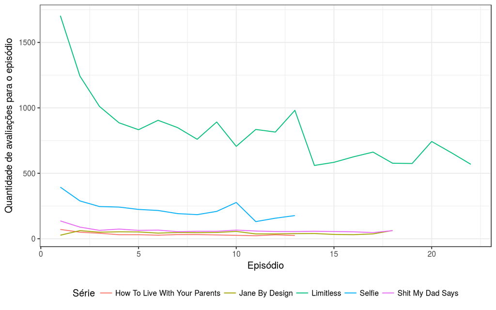

```r
ggplot(dados_canceladas1,
       aes(x = series_ep,
           y = user_votes,
           color = series_name)) +
        geom_line() +
    labs(x = "Episódio",
         y = "Quantidade de avaliações para o episódio",
         color = "Série") +
        theme(legend.position="bottom")
```

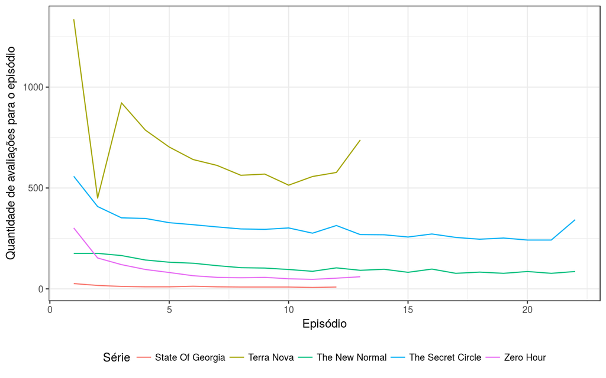

```r
ggplot(dados_canceladas2,
       aes(x = series_ep,
           y = user_votes,
           color=series_name)) +
        geom_line() +
    labs(x = "Episódio",
         y = "Quantidade de avaliações para o episódio",
         color = "Série") +
        theme(legend.position="bottom")
```

Agora, vamos agrupar todas as séries e obter o valor máximo / minimo e a diferença proporcional entre esses valores. (Para as séries não canceladas, iremos analisar apenas a primeira temporada).

```r
series_primeira_temp = dados %>%
    filter(season == 1) %>%
           group_by(series_name) %>%
            summarise(n = n(),
                      max_user_votes = max(user_votes),
                      min_user_votes = min(user_votes),
                      season = max(season))
series_primeira_temp = transform(series_primeira_temp,
                                 diferenca = (max_user_votes - min_user_votes) / max_user_votes)

dados_canceladas_votes <- dados_canceladas %>%
    group_by(series_name) %>%
        summarise(max_user_votes = max(user_votes),
                  min_user_votes = min(user_votes),
                  season = max(season))
dados_canceladas_votes  = transform(dados_canceladas_votes,
                                 diferenca = (max_user_votes - min_user_votes) / max_user_votes)
```

Abaixo vamos calcular a média e a mediana da variação entre o episódio dom maior quantidade de votos e menor quantidade para os dois grupos (Todas as séries, séries canceladas).

```r
str = paste("Séries canceladas \nMedia de variação maior quantidade de votos - menor quantidade de votos: ",
            mean(dados_canceladas_votes$diferenca),
            "\nMediana de variação maior quantidade de votos - menor quantidade de votos: ",
            median(dados_canceladas_votes$diferenca),
            '\n---\n',
            "Todas as séries - Primeira temporada \n",
            "Media de variação maior quantidade de votos - menor quantidade de votos: ",
            mean(series_primeira_temp$diferenca),
            "\nMediana de variação maior quantidade de votos - menor quantidade de votos: ",
            median(series_primeira_temp$diferenca)
            ,sep = "")
cat(str)
```

```
Séries canceladas
Media de variação maior quantidade de votos - menor quantidade de votos: 0.66081447819453
Mediana de variação maior quantidade de votos - menor quantidade de votos: 0.665469135005638
---
Todas as séries - Primeira temporada
Media de variação maior quantidade de votos - menor quantidade de votos: 0.526527530300024
Mediana de variação maior quantidade de votos - menor quantidade de votos: 0.516726403823178
```

Como podemos ver, a média e a mediana são maiores para para as séries que são canceladas. Então, uma queda na quantidade de votos nos episódios da série pode ser um indicador de que a série será (ou já foi) cancelada.

# 4. As séries que possuem episódios com nota alta são também as séries mais bem avaliadas?

Primeiros vamos obter os episódios que contem a nota máxima para o conjunto de dados. Ao ordenarmos os dados, vemos que 11 apresentam 9.9.

```r
dados[order(-dados$user_rating),][1:11,] %>%
    select(series_name, series_ep, user_rating)
```

```
# A tibble: 11 x 3
   series_name        series_ep user_rating
   <chr>                  <int>       <dbl>
 1 Breaking Bad              46         9.9
 2 Breaking Bad              60         9.9
 3 Breaking Bad              62         9.9
 4 Arrow                    115         9.9
 5 Person Of Interest        79         9.9
 6 Person Of Interest       103         9.9
 7 Game of Thrones           29         9.9
 8 Game of Thrones           48         9.9
 9 Game of Thrones           59         9.9
10 Game of Thrones           60         9.9
11 Hannibal                  26         9.9
```

A nota máxima foi atribuída a 4 episódios de Game of Thrones, 3 episódios de Breaking Bad, 2 episódios de Person of Interest, e 1 episódio de Arrow e Hannibal. Para selecionar as 5 séries mais bem avaliadas do conjunto, serão calculadas as médias de avaliação.

```r
medias_series = dados %>%
    group_by(series_name) %>%
    summarise(media = mean(user_rating),
              maximo = max(user_rating))
medias_series[order(-medias_series$media),][1:5,]
```

```
# A tibble: 5 x 3
  series_name        media maximo
  <chr>              <dbl>  <dbl>
1 Person Of Interest  9.13    9.9
2 The Originals       9.06    9.7
3 Game of Thrones     9.05    9.9
4 Fargo               9.03    9.6
5 Super Girl          9       9
```

Entre as 5 séries com maior média de avaliação, temos Person of Interest e Game of Thrones que apresentam episódios com nota máxima. Se nos restringissemos apenas a esses dados, não teriamos como comprovar uma correlação entre os valores. Porém podemos explorar melhor todo o conjunto de dados e fazer um gráfico com todas as séries levando em consideração a maior nota obtida e a média de avaliação para a série.

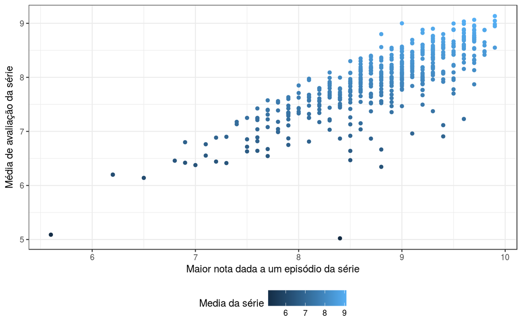

```r
ggplot(medias_series,
       aes(x = maximo,
           y = media,
           color=media)) +
        geom_point() +
    labs(x = "Maior nota dada a um episódio da série",
         y = "Média de avaliação da série",
         color = "Media da série") +
        theme(legend.position="bottom")
```

O gráfico nos ajuda a compreender que existe sim uma correlação entre esses valores. E sim, as séries que contem episódios com notas maiores provavelmente são as séries mais bem avaliadas.